# Tidy Tuesday (2023-08-15): Spam mail

```r
library(tidyverse)
library(caret)
```

```r
library(corrplot)
library(tidymodels)
library(usemodels)
library(future)
knitr::opts_chunk$set(echo = TRUE, fig.width = 4.5, fig.height = 2.5)
```

# Load data

```r
df <- readr::read_csv('https://raw.githubusercontent.com/rfordatascience/tidytuesday/master/data/2023/2023-08-15/spam.csv') %>%
  mutate(yesno = factor(yesno == 'y', levels=c(TRUE, FALSE)))
```

# Data dictionary

```
variable  class       description
crl.tot   double      Total length of uninterrupted sequences of capitals
dollar    double        Occurrences of the dollar sign, as percent of total number of characters
bang        double      Occurrences of ‘!’, as percent of total number of characters
money     double        Occurrences of ‘money’, as percent of total number of characters
n000        double      Occurrences of the string ‘000’, as percent of total number of words
make        double      Occurrences of ‘make’, as a percent of total number of words
yesno     character     Outcome variable, a factor with levels 'n' not spam, 'y' spam
```

The outcome variable is `yesno`, a character type, and all of the other variables are of a numeric type.

We can see that a lot of the feature engineering has already been done. It seems that whoever prepared this dataset has determined that spam emails can be meaningfully identified by:

- SHOUTING! (`crl.tot`, `bang`)
- and talk of making money (`make`, `money`, `dollar`) at values of 1,000 or greater (`n000`)

That definitely matches my experience reading spam!

# What can we do with this data?

How can we apply ML to this data, or what can we do with it? We can look at this as either a supervised or unsupervised ML problem. For supervised ML, we might be aiming to predict spam – to develop a spam filter, for example. For unsupervised ML, we might be aiming to identify different kinds of mail within the spam and not-spam classes.

Let’s start with supervised ML / prediction.

# Supervised ML: Predicting spam / spam filter

## Average values, by spam

Let’s start by looking at some averages (mean and median), split by the outcome variable.

```r
df %>%
  group_by(yesno) %>%
  summarise_all(mean)
```

```
## # A tibble: 2 × 7
##   yesno crl.tot dollar  bang  money    n000   make
##   <fct>   <dbl>  <dbl> <dbl>  <dbl>   <dbl>  <dbl>
## 1 TRUE     471. 0.174  0.514 0.213  0.247   0.152
## 2 FALSE    161. 0.0116 0.110 0.0171 0.00709 0.0735
```

We can see that on average, spam emails have higher mean values for each of the predictors. No surprise there.

However, the medians of some variables are zero, which suggests those variables have heavily positively skewed distributions with many zero values (sometimes called “zero-inflation”).

```r
df %>%
  group_by(yesno) %>%
  summarise_all(median)
```

```
## # A tibble: 2 × 7
##   yesno crl.tot dollar  bang money  n000  make
##   <fct>   <dbl>  <dbl> <dbl> <dbl> <dbl> <dbl>
## 1 TRUE      194   0.08 0.331     0     0     0
## 2 FALSE      54   0    0         0     0     0
```

We can confirm this by looking at the counts of zero values, in relation to the total counts.

```r
no = df %>% filter(yesno == FALSE) %>% select(-yesno)
yes = df %>% filter(yesno == TRUE) %>% select(-yesno)

round(colSums(no>0)/nrow(no)*100)
```

```
## crl.tot  dollar    bang   money    n000    make
##     100      10      27       2       3      15
```

```r
round(colSums(yes>0)/nrow(yes)*100)
```

```
## crl.tot  dollar    bang   money    n000    make
##     100      61      83      38      33      35
```

## Distributions, by spam

Next, let’s look at the distributions.

For these plots, since they’re all have extreme skew, I’m going to truncate them at the 90th percentile and look at the left side where most of the mass is.

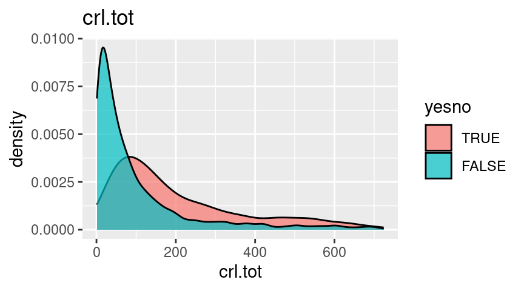

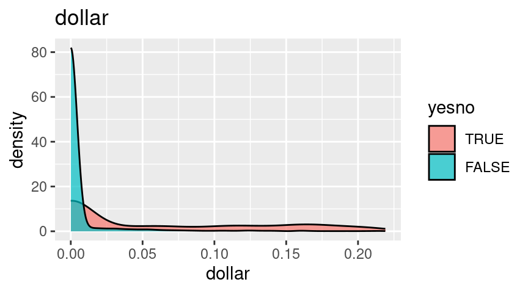

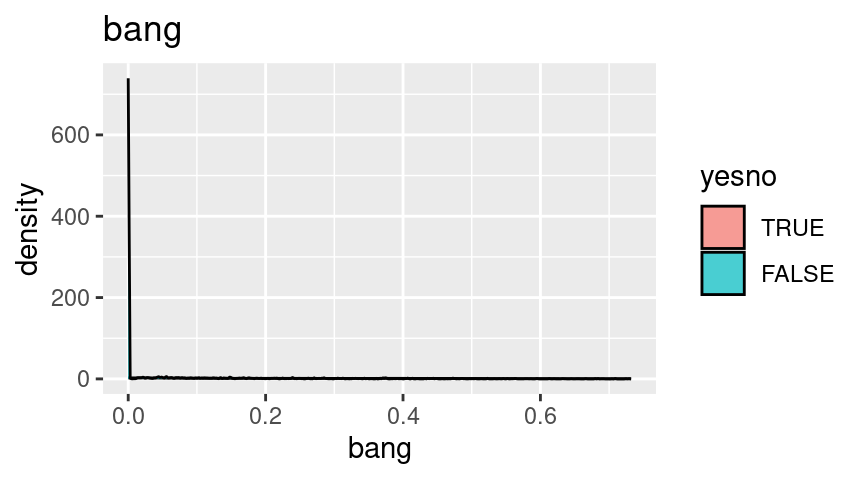

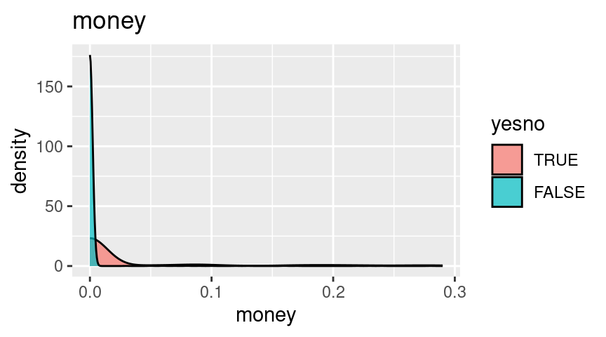

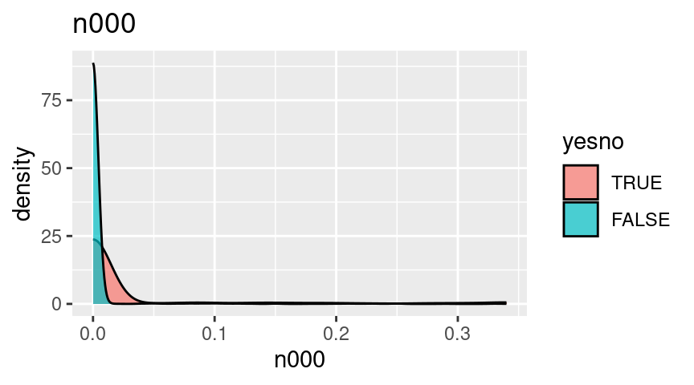

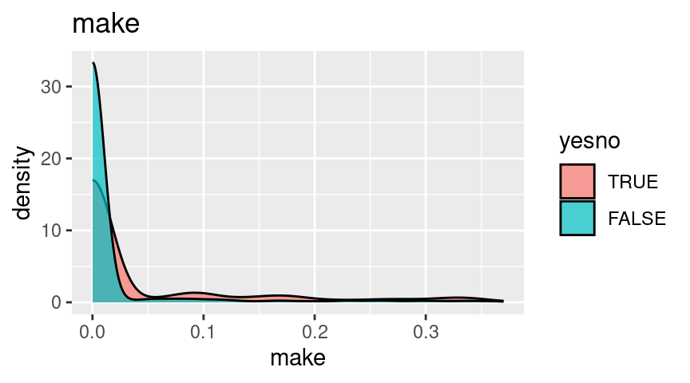

```r
for (c in c('crl.tot', 'dollar', 'bang', 'money', 'n000', 'make')){

  qtile_90 <- quantile(df[[c]], .90)

  df %>%
    filter(!!sym(c) < qtile_90) %>%
    ggplot(aes(x = !!sym(c), fill=yesno)) +
      geom_density(alpha=.7) +
      ggtitle(c) -> plot
  print(plot)

}
```

## Feature correlations

It doesn’t look like the features are very strongly correlated. The strongest correlation is between `n000` and `dollar`, which is not particularly surprising since I would expect that “000” would tend to appear in the context of a dollar value like “$1000”.

```r
df %>%
  select(-yesno) %>%
  cor(use = "complete.obs")
```

```
##            crl.tot    dollar       bang      money       n000       make
## crl.tot 1.00000000 0.2019477 0.03632120 0.08099318 0.16597657 0.08916478
## dollar  0.20194768 1.0000000 0.14291296 0.10469131 0.31097072 0.11741853
## bang    0.03632120 0.1429130 1.00000000 0.05107591 0.07010334 0.05829200
## money   0.08099318 0.1046913 0.05107591 1.00000000 0.05258693 0.18815518
## n000    0.16597657 0.3109707 0.07010334 0.05258693 1.00000000 0.13407211
## make    0.08916478 0.1174185 0.05829200 0.18815518 0.13407211 1.00000000
```

If we convert the features to boolean, we can see that the presence of features have stronger correlations. The strongest correlation is again between `dollar` and `n000`, but `money` and `dollar` also occur together more often than not.

```r
df %>%
  select(-yesno, -crl.tot) %>%
  mutate(dollar = dollar > 0,
         bang = bang > 0,
         money = money > 0,
         n000 = n000 > 0,
         make = make > 0
  ) %>%
  cor(use = "complete.obs")
```

```
##           dollar      bang     money      n000      make
## dollar 1.0000000 0.3779057 0.5058803 0.5372603 0.4133374
## bang   0.3779057 1.0000000 0.3290505 0.3404896 0.2641339
## money  0.5058803 0.3290505 1.0000000 0.4140177 0.4092119
## n000   0.5372603 0.3404896 0.4140177 1.0000000 0.3757565
## make   0.4133374 0.2641339 0.4092119 0.3757565 1.0000000
```

## Simple classification algorithm

Just for fun, let’s see how well we can distinguish spam vs. not spam using a simple heuristic.

I’ll label anything as spam if it contained at least 1 “money”, “$”, “000”, and “!” OR if it contained more than 100 uninterrupted sequences of capital letters and at least 1 “1”. This is just what comes to mind after looking at the frequency plots above.

```r
df %>%
  mutate(simple_spam_flag = factor((money > 0 & dollar > 0 & bang > 0 & n000 > 0) |
                                     (crl.tot > 100 & bang > 0),
                                   levels=c(TRUE, FALSE))
         ) -> df_flag
```

This simple classification algorithm achieved an accuracy of 79%. This doesn’t seem too bad. But what is a good baseline of performance?

```r
confusionMatrix(df_flag$simple_spam_flag, df_flag$yesno, mode='everything')
```

```
## Confusion Matrix and Statistics
##
##           Reference
## Prediction TRUE FALSE
##      TRUE  1172   309
##      FALSE  641  2479
##
##                Accuracy : 0.7935
##                  95% CI : (0.7815, 0.8051)
##     No Information Rate : 0.606
##     P-Value [Acc > NIR] : < 2.2e-16
##
##                   Kappa : 0.5533
##
##  Mcnemar's Test P-Value : < 2.2e-16
##
##             Sensitivity : 0.6464
##             Specificity : 0.8892
##          Pos Pred Value : 0.7914
##          Neg Pred Value : 0.7946
##               Precision : 0.7914
##                  Recall : 0.6464
##                      F1 : 0.7116
##              Prevalence : 0.3940
##          Detection Rate : 0.2547
##    Detection Prevalence : 0.3219
##       Balanced Accuracy : 0.7678
##
##        'Positive' Class : TRUE
##
```

We can see that the base rate of spam is 39%.

```r
mean(df$yesno == TRUE)
```

```
## [1] 0.3940448
```

A good baseline model might be to predict the majority class, which in this case is not-spam.

This “always predict FALSE” baseline model can be expected to achieve 1 minus the base rate of spam (i.e., 61%), and we can see that this is the case if we construct just such a model. This tells us that the heuristic model above is quite a bit better than a completely naive model.

```r
confusionMatrix(factor(rep('FALSE',nrow(df_flag))), df_flag$yesno, mode='everything')
```

```
## Confusion Matrix and Statistics
##
##           Reference
## Prediction TRUE FALSE
##      TRUE     0     0
##      FALSE 1813  2788
##
##                Accuracy : 0.606
##                  95% CI : (0.5917, 0.6201)
##     No Information Rate : 0.606
##     P-Value [Acc > NIR] : 0.5064
##
##                   Kappa : 0
##
##  Mcnemar's Test P-Value : <2e-16
##
##             Sensitivity : 0.000
##             Specificity : 1.000
##          Pos Pred Value :   NaN
##          Neg Pred Value : 0.606
##               Precision :    NA
##                  Recall : 0.000
##                      F1 :    NA
##              Prevalence : 0.394
##          Detection Rate : 0.000
##    Detection Prevalence : 0.000
##       Balanced Accuracy : 0.500
##
##        'Positive' Class : TRUE
##
```

## Random forest

Next, I’ll try a random forest model. This should perform much better than my simple heurstic model.

```r
split <- initial_split(df)
train <- training(split)
test <- testing(split)
cv <- vfold_cv(train)
```

I’ll use `usemodels::use_ranger` to give me a starting template.

```r
use_ranger(yesno ~ ., train)
```

```
## ranger_recipe <-
##   recipe(formula = yesno ~ ., data = train)
##
## ranger_spec <-
##   rand_forest(mtry = tune(), min_n = tune(), trees = 1000) %>%
##   set_mode("classification") %>%
##   set_engine("ranger")
##
## ranger_workflow <-
##   workflow() %>%
##   add_recipe(ranger_recipe) %>%
##   add_model(ranger_spec)
##
## set.seed(48971)
## ranger_tune <-
##   tune_grid(ranger_workflow, resamples = stop("add your rsample object"), grid = stop("add number of candidate points"))
```

I’ll remove the parameter tuning to keep things simple.

```r
ranger_recipe <-
  recipe(formula = yesno ~ ., data = df)

ranger_spec <-
  rand_forest(trees = 1000) %>%
  set_mode("classification") %>%
  set_engine("ranger")

ranger_workflow <-
  workflow() %>%
  add_recipe(ranger_recipe) %>%
  add_model(ranger_spec)
```

Next, I’ll fit the model using a resampling approach.

```r
set.seed(100)
plan(multisession)

fit_rf <- fit_resamples(
  ranger_workflow,
  cv,
  metrics = metric_set(accuracy, sens, spec, roc_auc),
  control = control_resamples(verbose = TRUE,
                              save_pred = TRUE,
                              extract = function(x) x)
)
```

[output not shown]

[output not shown]

[output not shown]

[output not shown]

[output not shown]

[output not shown]

[output not shown]

[output not shown]

[output not shown]

[output not shown]

[output not shown]

[output not shown]

[output not shown]

[output not shown]

[output not shown]

[output not shown]

[output not shown]

[output not shown]

[output not shown]

[output not shown]

[output not shown]

[output not shown]

[output not shown]

[output not shown]

[output not shown]

[output not shown]

[output not shown]

[output not shown]

[output not shown]

[output not shown]

[output not shown]

[output not shown]

[output not shown]

[output not shown]

[output not shown]

[output not shown]

[output not shown]

[output not shown]

[output not shown]

[output not shown]

[output not shown]

[output not shown]

[output not shown]

[output not shown]

[output not shown]

[output not shown]

[output not shown]

[output not shown]

[output not shown]

[output not shown]

[output not shown]

[output not shown]

[output not shown]

[output not shown]

[output not shown]

[output not shown]

[output not shown]

[output not shown]

[output not shown]

[output not shown]

```r
fit_rf %>%
  collect_metrics()
```

```
## # A tibble: 4 × 6
##   .metric  .estimator  mean     n std_err .config
##   <chr>    <chr>      <dbl> <int>   <dbl> <chr>
## 1 accuracy binary     0.878    10 0.00428 Preprocessor1_Model1
## 2 roc_auc  binary     0.923    10 0.00324 Preprocessor1_Model1
## 3 sens     binary     0.780    10 0.00683 Preprocessor1_Model1
## 4 spec     binary     0.941    10 0.00487 Preprocessor1_Model1
```

Next, we can check the performance on the test set.

We can use `collect_metrics()` function on the last fit.

```r
ranger_workflow %>%
  last_fit(split) %>%
  collect_metrics()
```

```
## # A tibble: 2 × 4
##   .metric  .estimator .estimate .config
##   <chr>    <chr>          <dbl> <chr>
## 1 accuracy binary         0.889 Preprocessor1_Model1
## 2 roc_auc  binary         0.932 Preprocessor1_Model1
```

Or we can use `confusionMatrix()` to get a bit more information.

```r
ranger_workflow %>%
  last_fit(split) %>%
  extract_workflow() -> final_model

confusionMatrix(predict(final_model, test)$.pred_class, test$yesno, mode='everything', positive='TRUE')
```

```
## Confusion Matrix and Statistics
##
##           Reference
## Prediction TRUE FALSE
##      TRUE   378    37
##      FALSE   87   649
##
##                Accuracy : 0.8923
##                  95% CI : (0.8729, 0.9096)
##     No Information Rate : 0.596
##     P-Value [Acc > NIR] : < 2.2e-16
##
##                   Kappa : 0.7723
##
##  Mcnemar's Test P-Value : 1.081e-05
##
##             Sensitivity : 0.8129
##             Specificity : 0.9461
##          Pos Pred Value : 0.9108
##          Neg Pred Value : 0.8818
##               Precision : 0.9108
##                  Recall : 0.8129
##                      F1 : 0.8591
##              Prevalence : 0.4040
##          Detection Rate : 0.3284
##    Detection Prevalence : 0.3606
##       Balanced Accuracy : 0.8795
##
##        'Positive' Class : TRUE
##
```

Performance on the test set is similar to the training performance. Overall, accuracy is pretty good. It seems we’re letting some spam mail through, which is why we see that sensitivity is somewhat low. For a spam detection filter, we’d want to bias towards minimizing false positives, and here we see that the specificity was quite good at ~95%.

# Unsupervised learning

Can we identify different types of spam mail? Intuitively, we might expect that some spam mail is about making money, and other spam mail is not.

I’ll use kmeans clustering to identify two clusters.

```r
df %>% filter(yesno == TRUE) %>% select(-yesno) -> df_spam
kclust <- kmeans(df_spam, centers = 2)
kclust
```

```
## K-means clustering with 2 clusters of sizes 1646, 167
##
## Cluster means:
##     crl.tot    dollar      bang     money      n000      make
## 1  285.6889 0.1606719 0.5265565 0.2044714 0.2213852 0.1423937
## 2 2293.3473 0.3105569 0.3871198 0.2957485 0.5000599 0.2503593
##
## Clustering vector:
##    [1] 1 1 2 1 1 1 1 1 1 1 1 1 1 1 1 1 1 1 1 1 1 2 1 1 1 2 1 1 1 1 1 1 1 1 1 1 1
##   [38] 1 1 1 1 1 1 1 1 1 1 1 2 1 1 1 1 1 1 1 1 1 1 1 1 1 1 1 1 1 1 1 1 1 1 1 1 1
##   [75] 1 1 1 1 1 1 1 1 1 1 1 1 1 1 1 1 1 2 2 2 1 1 1 1 1 1 1 1 1 1 1 1 1 1 1 1 1
##  [112] 1 1 1 1 1 1 1 1 1 1 1 2 1 1 1 1 1 1 1 1 1 1 1 1 1 1 1 1 1 1 1 2 1 1 1 1 1
##  [149] 1 1 1 1 1 1 1 1 1 1 1 1 1 1 1 1 1 1 1 1 1 1 1 1 1 1 1 1 1 1 1 1 1 1 1 1 1
##  [186] 1 1 1 1 1 1 1 1 1 1 1 1 1 1 1 1 1 1 1 1 1 1 1 1 2 1 1 1 1 1 1 1 1 2 1 1 1
##  [223] 1 1 1 1 1 1 1 1 1 1 1 1 1 1 1 1 1 1 1 1 1 1 1 1 1 1 1 1 1 1 2 1 1 1 1 1 1
```

[output cut: 51 more lines]

```r
tidy(kclust)
```

```
## # A tibble: 2 × 9
##   crl.tot dollar  bang money  n000  make  size   withinss cluster
##     <dbl>  <dbl> <dbl> <dbl> <dbl> <dbl> <int>      <dbl> <fct>
## 1    286.  0.161 0.527 0.204 0.221 0.142  1646 135346204. 1
## 2   2293.  0.311 0.387 0.296 0.500 0.250   167 487069265. 2
```

Here we can see two clusters have emerged. The first cluster, which most spam mail was bucketed into, contained more bangs, fewer dollar signs, fewer 000s, fewer make, and fewer sequences of capital letters than the second cluster. Based on this, it would seem that the second cluster is more about making money than the first cluster.